# Final project

# 8. Use a violin plot to illustrate how these clusters relate to the log-mass of the exoplanet.

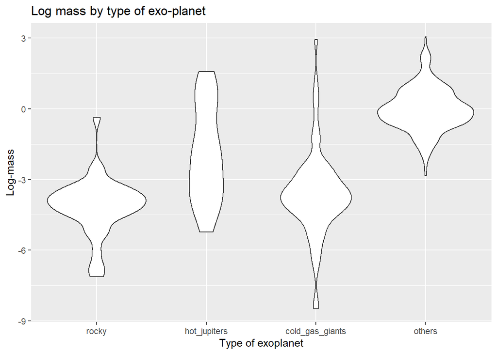

```r
p <- ggplot(n_exo_data, aes(x=type, y=log(mass))) +
  geom_violin()+
  xlab('Type of exoplanet') +
  ggtitle("Log mass by type of exo-planet")+
  ylab('Log-mass')

p
```

# 9. Transform r_asc and decl into two new variables that are the same varibales but in values of seconds. Use these as coordinates to represent a celestial map for the exoplanets.

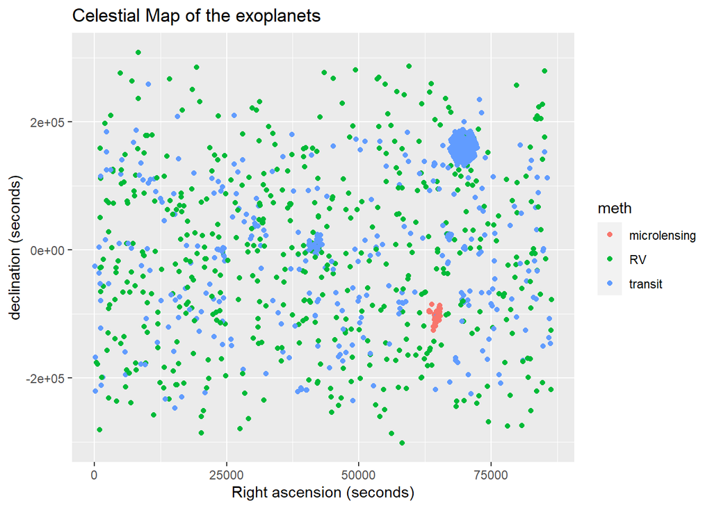

```r
#We first address the variable e_asc
exo_data$r_asc <- gsub(" ", ":", exo_data$r_asc, fixed=TRUE)#Transformed to hh:mm:ss
exo_data$r_asc <- hms(exo_data$r_asc)
exo_data$r_asc_sec <- period_to_seconds(exo_data$r_asc)

#we later address the variable decl
exo_data$decl <- gsub(" ", ":", exo_data$decl, fixed=TRUE)

#Transformed to dd:mm:ss
exo_data$decl <- hms(exo_data$decl)
exo_data$decl_sec <- period_to_seconds(exo_data$decl)

#Now we plot the results
ggplot(exo_data, aes(r_asc_sec, decl_sec, color= meth)) +
  geom_point() +
  ggtitle("Celestial Map of the exoplanets")+
  xlab("Right ascension (seconds)")+
  ylab("declination (seconds)")
```

# 10. Create an animated time series where multiple lines illustrate the evolution over time of the total number of exoplanets discovered for each method up to that year.

```r
#We create a new variable
time_series <- exo_data %>% group_by(meth, year) %>%
  summarise(count = length(meth)) %>%
  mutate(Ncount = cumsum(count))
```

[figure not shown]

```r
#Na values excluded
time_series <- na.omit(time_series)
#We create the plot
p<- time_series %>%
  ggplot( aes(x=year, y=Ncount, group=meth, color=meth)) +
  geom_line() +
  geom_point() +
  theme_ipsum() +
  scale_color_viridis(discrete = TRUE) +
  ggtitle("Exo-planet Mass and distance by method")+
  scale_x_log10()+
  xlab("Year of discovery")+
  ylab("number of discoveries")+
  transition_reveal(year)
#print the plot
p
```

```r
#We create a new data for the model
lm_exo_data <-  exo_data %>%select(period,host_mass,host_temp,axis)

#Exclude the na
lm_exo_data <- na.omit(lm_exo_data)

#Convert into log-scale
lm_exo_data <- lm_exo_data %>%
  mutate(host_mass = log(host_mass),
         host_temp = log(host_temp),
         axis = log(axis))


#Create the model
mod <- lm_exo_data %$% lm(period ~ host_mass + host_temp + axis)
summary(mod)
```

```
##
## Call:
## lm(formula = period ~ host_mass + host_temp + axis)
##
## Residuals:
##     Min      1Q  Median      3Q     Max
## -2239.7  -483.0   -58.7   267.2 11584.4
##
## Coefficients:
##             Estimate Std. Error t value Pr(>|t|)
## (Intercept) -8853.69    1700.35  -5.207 2.24e-07 ***
## host_mass    -604.04      77.72  -7.772 1.61e-14 ***
## host_temp    1168.51     198.69   5.881 5.24e-09 ***
## axis          480.88      15.08  31.890  < 2e-16 ***
## ---
## Signif. codes:  0 '***' 0.001 '**' 0.01 '*' 0.05 '.' 0.1 ' ' 1
##
## Residual standard error: 850.1 on 1242 degrees of freedom
## Multiple R-squared:  0.4513, Adjusted R-squared:  0.4499
## F-statistic: 340.4 on 3 and 1242 DF,  p-value: < 2.2e-16
```